# Interpretation and product narrative

This notebook explains model behavior and turns the results into business actions. Permutation importance is computed on preprocessed test features so names align with `ColumnTransformer.get_feature_names_out()`. Optional SHAP output is included for Model B HGB when available.

The final section summarizes key drivers, segment-level churn patterns, and practical actions, then exports the report to `outputs/reports/final_story.html`.

```python
import sys
from pathlib import Path

_cwd = Path.cwd().resolve()
_root = None
for _p in [_cwd, *_cwd.parents]:
    if (_p / "src" / "config.py").is_file():
        _root = _p
        break
if _root is None:
    raise FileNotFoundError(
        "Could not find project root (src/config.py). In Jupyter: %cd path/to/telecom-churn-income-integration"
    )
if str(_root) not in sys.path:
    sys.path.insert(0, str(_root))
```

## 1. Train and generate interpretation artifacts

`run_interpretation()` retrains the same A/B setup as notebook 04, writes permutation importance outputs for Model B, optionally writes Model A artifacts, and saves a SHAP summary for B HGB when SHAP succeeds. The default row subsampling keeps runtime manageable on wide one-hot feature spaces.

```python
from src.interpret import run_interpretation

out = run_interpretation()
out["perm_importance_modelB"].head(20)
```

|  | feature | importance_mean | importance_std |
| --- | --- | --- | --- |
| 0 | num__price_sensitivity_proxy | 0.077747 | 0.008707 |
| 1 | cat__contract_Month-to-month | 0.061893 | 0.008175 |
| 2 | cat__dependents_No | 0.050944 | 0.006723 |
| 3 | cat__contract_Two year | 0.012915 | 0.003007 |
| 4 | cat__internet_service_Fiber optic | 0.008471 | 0.001433 |
| 5 | num__zip_code | 0.006630 | 0.001734 |
| 6 | cat__online_security_No | 0.005343 | 0.001258 |
| 7 | cat__payment_method_Electronic check | 0.004293 | 0.000987 |
| 8 | num__cltv | 0.003147 | 0.001715 |
| 9 | num__monthly_charges | 0.003136 | 0.002447 |
| 10 | cat__multiple_lines_No | 0.002858 | 0.000694 |
| 11 | cat__paperless_billing_No | 0.002385 | 0.001411 |
| 12 | num__total_charges | 0.002303 | 0.001505 |
| 13 | cat__tech_support_No | 0.001959 | 0.001171 |
| 14 | num__tenure_months | 0.001833 | 0.001994 |
| 15 | cat__partner_No | 0.001546 | 0.001301 |
| 16 | cat__phone_service_No | 0.001413 | 0.000400 |
| 17 | cat__internet_service_DSL | 0.001267 | 0.000520 |
| 18 | cat__senior_citizen_No | 0.000972 | 0.000455 |
| 19 | cat__gender_Female | 0.000698 | 0.000506 |

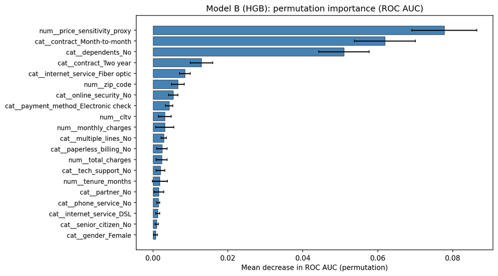

```python
from IPython.display import Image, display
from src.config import OUTPUTS_FIGURES

png_b = OUTPUTS_FIGURES / "perm_importance_modelB.png"
if png_b.exists():
    display(Image(filename=str(png_b)))
else:
    print("Run not found:", png_b)
```

## 2. Segment insights by customer group

This section saves churn-rate charts for contract type, payment method, tenure bucket, and income quartile. The figures are written to `outputs/figures/` for reporting and review.

```python
import pandas as pd

from src.config import OUTPUTS_FIGURES, TELCO_WITH_FEATURES_PATH
from src.plots import plot_churn_rate

df = pd.read_parquet(TELCO_WITH_FEATURES_PATH)
segments = [
    ("contract", "segment_churn_contract"),
    ("payment_method", "segment_churn_payment_method"),
    ("tenure_bucket", "segment_churn_tenure_bucket"),
    ("income_quartile", "segment_churn_income_quartile"),
]
for col, stem in segments:
    if col in df.columns:
        plot_churn_rate(df, col, OUTPUTS_FIGURES / f"{stem}.png")
        print("Saved", stem)
    else:
        print("Skip (missing column):", col)
```

```
Saved segment_churn_contract
Saved segment_churn_payment_method
Saved segment_churn_tenure_bucket
Saved segment_churn_income_quartile
```

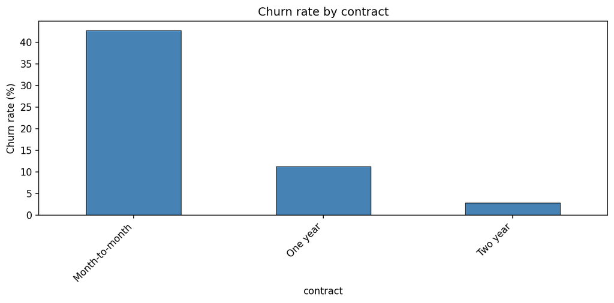

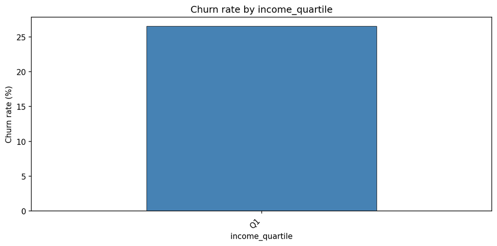

```python
from IPython.display import Image, display

for stem in ["segment_churn_contract", "segment_churn_income_quartile"]:
    p = OUTPUTS_FIGURES / f"{stem}.png"
    if p.exists():
        display(Image(filename=str(p)))
```

## 3. How to read the drivers

Permutation importance shows how much ROC AUC drops when one transformed feature is shuffled on holdout data. Larger positive values usually mean the model depends on that signal more strongly. One-hot encoded columns appear as `cat__<original>_<level>`, so one original field can appear across multiple bars.

## 4. Product actions

First, prioritize retention tests for high-risk contract and payment groups that appear in both model drivers and segment charts. Second, strengthen onboarding for early-tenure customers and provide clearer support and security messaging where service features rank highly. Third, use income quartile as context for messaging and offer design, while keeping compliance checks in place.

Revisit these actions after reviewing your latest permutation rankings and segment plots.

## 5. Optional SHAP for Model B HGB

If `shap` is installed and `TreeExplainer` runs successfully, open `outputs/figures/shap_summary_modelB_hgb.png`. If the file is missing, keep SHAP as an optional note in the written report.

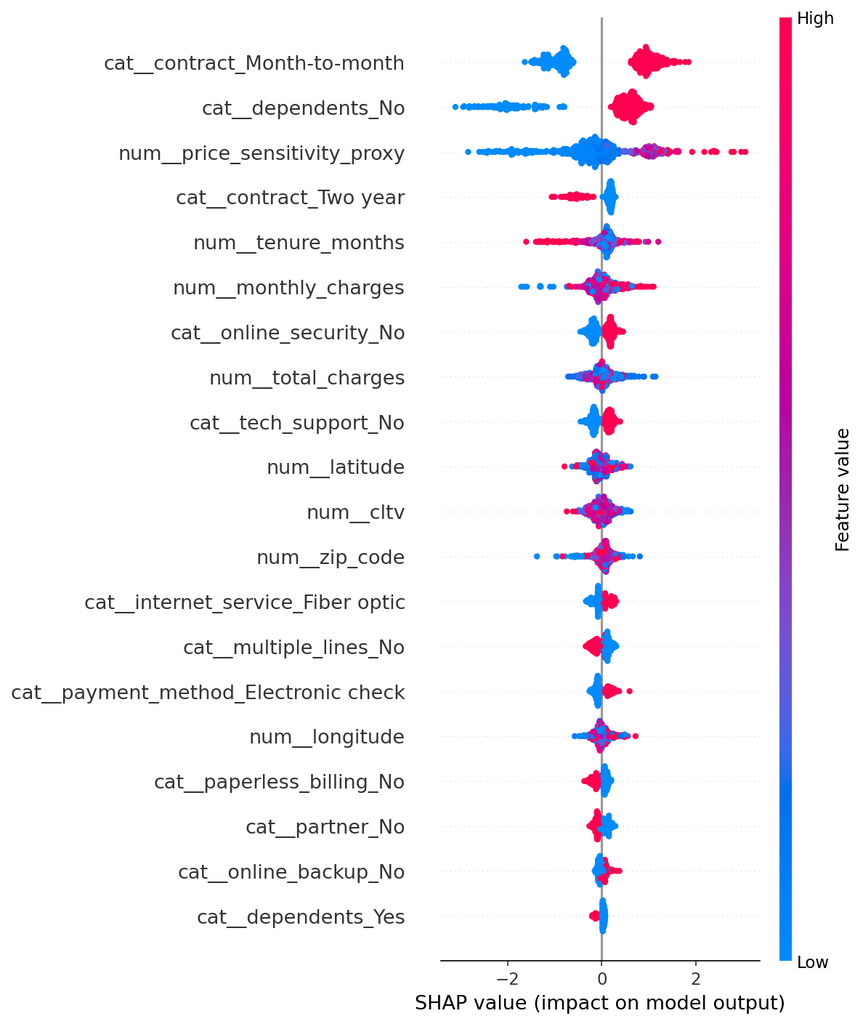

```python
from pathlib import Path

from IPython.display import Image, display
from src.config import OUTPUTS_FIGURES

shap_png = OUTPUTS_FIGURES / "shap_summary_modelB_hgb.png"
if shap_png.exists():
    display(Image(filename=str(shap_png)))
else:
    print("SHAP figure not present:", shap_png)
```

## Conclusion

This project asked whether Census income context improves churn prediction beyond internal telecom features. The pipeline cleaned leakage-prone fields, merged ACS income by state, engineered features, and compared Model A and Model B on the same stratified split.

On this run, logistic regression improved slightly with income features, while hist gradient boosting produced the same headline ROC AUC and PR AUC for A and B. Driver analysis still highlighted price sensitivity, month-to-month contracts, dependents, fiber service, and electronic check as key signals.

Use segment charts and model scores together to target outreach. Practical next steps include retention tests for high-risk contract and payment groups, stronger early-tenure onboarding, and refined affordability-focused messaging. If stronger lift from external data is required, test finer geographic granularity in a follow-up iteration.

Full write-up is in `outputs/reports/conclusion.md`. Resume-ready lines are in `outputs/reports/resume_bullets.md`.

## 6. Export this notebook to HTML

Run the next cell to write `outputs/reports/final_story.html`. It uses `jupyter nbconvert` from the current Python environment.

```python
import subprocess
import sys
from pathlib import Path

_cwd = Path.cwd().resolve()
_root = None
for _p in [_cwd, *_cwd.parents]:
    if (_p / "src" / "config.py").is_file():
        _root = _p
        break
if _root is None:
    raise FileNotFoundError(
        "Could not find project root (src/config.py). In Jupyter: %cd path/to/telecom-churn-income-integration"
    )
if str(_root) not in sys.path:
    sys.path.insert(0, str(_root))

from src.config import OUTPUTS_REPORTS, PROJECT_ROOT
from src.notebook_utils import repair_notebook_file

OUTPUTS_REPORTS.mkdir(parents=True, exist_ok=True)
nb_path = PROJECT_ROOT / "notebooks" / "05_interpretation_and_story.ipynb"
# Some Jupyter builds save outputs without fields nbconvert's validator requires; fix before export.
repair_notebook_file(nb_path)
cmd = [
    sys.executable,
    "-m",
    "jupyter",
    "nbconvert",
    "--to",
    "html",
    str(nb_path),
    "--output-dir",
    str(OUTPUTS_REPORTS),
    "--output",
    "final_story.html",
]
r = subprocess.run(cmd, cwd=str(PROJECT_ROOT), capture_output=True, text=True)
if r.returncode != 0:
    print(r.stderr or r.stdout)
    raise RuntimeError(f"nbconvert failed with exit {r.returncode}")
print("Wrote", OUTPUTS_REPORTS / "final_story.html")
```

```
Wrote E:\Personal Project\telecom-churn-income-integration\outputs\reports\final_story.html
```